# Notes on Chapter 6

The Caveman Coder

2025-12-31

# Chapter 6: Spatial Modeling of Areal Data. Lip Cancer in Scotland.

Aim: Estimate the risk of lip cancer in Scortland, UK, and the proportion of the population engaged in agriculture, fishing, or forestry (AFF) for each of the Scottish counties, using the **R-INLA** package. Data are obtained from the **SpatialEpi** package.

## Data and map

Loading the **SpatialEpi** package and the relevant data for Scotland:

```r
library(SpatialEpi)
data(scotland)

class(scotland)
```

```
## [1] "list"
```

Inspecting the Scotland data:

```r
names(scotland)
```

```
## [1] "geo"             "data"            "spatial.polygon" "polygon"
```

Data dictionary for `scotland`: - `geo`: datafreame with names and centroid coordinates (eastings/northings) of each of the counties  
- `data`: dataframe with names, number of observed and expected lip cancer cases, and AFF values of each of the countries  
- `spatial.polygon`: `SpatialPolygons` object with the map of Scotland  
- `polygon`: polygon map of Scotland

```r
head(scotland$data)
```

```
##    county.names cases expected  AFF
## 1 skye-lochalsh     9      1.4 0.16
## 2  banff-buchan    39      8.7 0.16
## 3     caithness    11      3.0 0.10
## 4  berwickshire     9      2.5 0.24
## 5 ross-cromarty    15      4.3 0.10
## 6        orkney     8      2.4 0.24
```

Plotting the map of Scotland:

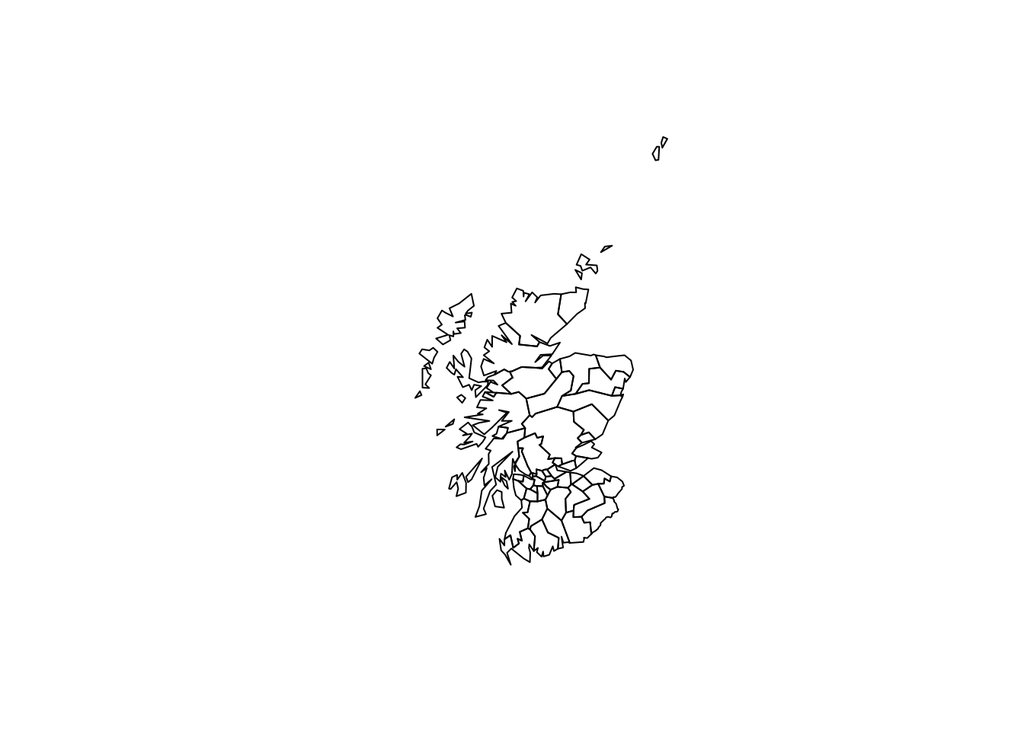

```r
map <- scotland$spatial.polygon
plot(map)
```

This `map` does not contain information about the CRS.

Specifying a CRS for `map` manually:

```r
proj4string(map) <- "+proj=tmerc +lat_0=49 +lon_0=-2 +k=0.9996012717 +x_0=400000 +y_0=-100000 +datum=OSGB36 +units=km +no_defs"
```

For more details on how to do this, see https://spatialreference.org/ref/epsg/27700/.

Preparing the map data for mapping using the **leaflet** package:

```r
library(sf)
```

```r
map <- st_as_sf(map)
map <- st_transform(map, crs = 4326)
```

The snippet above is necessary because **leaflet** expects the data to be specified in latitude and longitude using WGS84. The map was first transformed from `sp` to `sf` object and then `st_transform()` was used to convert the coordinates.

## Data preparation

Creating a dummy dataframe called `d` with columns containing the county ids, the observed and expected number of lip cancer cases, the AFF values, and the SIRs:

```r
d <- scotland$data[, c("county.names", "cases", "expected", "AFF")]
names(d) <- c("county", "Y", "E", "AFF")

head(d)
```

```
##          county  Y   E  AFF
## 1 skye-lochalsh  9 1.4 0.16
## 2  banff-buchan 39 8.7 0.16
## 3     caithness 11 3.0 0.10
## 4  berwickshire  9 2.5 0.24
## 5 ross-cromarty 15 4.3 0.10
## 6        orkney  8 2.4 0.24
```

Calculating the SIR using the formula from Chapter 5:

```r
d$SIR <- d$Y / d$E
head(d)
```

```
##          county  Y   E  AFF      SIR
## 1 skye-lochalsh  9 1.4 0.16 6.428571
## 2  banff-buchan 39 8.7 0.16 4.482759
## 3     caithness 11 3.0 0.10 3.666667
## 4  berwickshire  9 2.5 0.24 3.600000
## 5 ross-cromarty 15 4.3 0.10 3.488372
## 6        orkney  8 2.4 0.24 3.333333
```

### Adding data to map

Joining `d` with `map` using `cbind`:

```r
map <- cbind(map, d)
head(map)
```

```
## Simple feature collection with 6 features and 5 fields
## Geometry type: MULTIPOLYGON
## Dimension:     XY
## Bounding box:  xmin: -6.789691 ymin: 55.63418 xmax: -1.791961 ymax: 59.27929
## Geodetic CRS:  WGS 84
##          county  Y   E  AFF      SIR                       geometry
## 1 skye-lochalsh  9 1.4 0.16 6.428571 MULTIPOLYGON (((-5.493299 5...
## 2  banff-buchan 39 8.7 0.16 4.482759 MULTIPOLYGON (((-2.272216 5...
## 3     caithness 11 3.0 0.10 3.666667 MULTIPOLYGON (((-3.524618 5...
## 4  berwickshire  9 2.5 0.24 3.600000 MULTIPOLYGON (((-2.36695 55...
## 5 ross-cromarty 15 4.3 0.10 3.488372 MULTIPOLYGON (((-4.043716 5...
## 6        orkney  8 2.4 0.24 3.333333 MULTIPOLYGON (((-3.400826 5...
```

## Mapping SIRs

```r
library(leaflet)

l <- leaflet(map) |>
  addTiles()

pal <- colorNumeric(palette = "YlOrRd", domain = map$SIR)

l |> addPolygons(
  color = "grey", weight = 1,
  fillColor = ~ pal(SIR), fillOpacity = 0.5
) |>
  addLegend(
    pal = pal, values = ~ SIR, opacity = 0.5,
    title = "SIR",
    position = "bottomright"
  )
```

[interactive chart not shown]

Interactive map of lip cancer SIR in Scotland counties created with **leaflet**.

Adding “mouse hover effects” to the interactive map:

```r
labels <- sprintf(
  "<strong> %s </strong> <br/>
  Observed: %s <br/> Expected: %s <br/>
  AFF: %s <br/> SIR: %s",
  map$county, map$Y, round(map$E, 2), map$AFF, round(map$SIR, 2)
) |>
  lapply(htmltools::HTML)

l |> addPolygons(
  color = "grey", weight = 1,
  fillColor = ~ pal(SIR), fillOpacity = 0.5,
  highlightOptions = highlightOptions(weight = 4),
  label = labels,
  labelOptions = labelOptions(
    style = list(
      "font-weight" = "normal",
      padding = "3px 8px"
    ),
    textsize = "15px",
    direction = "auto"
  )
) |> addLegend(
  pal = pal,
  values = ~ SIR,
  opacity = 0.5,
  title = "SIR",
  position = "bottomright"
)
```

[interactive chart not shown]

The “mouse-hover” effects are created by adding the arguments `highlightOptions`, `label`, and `labelOptions` to `addPolygons()`. The labels are created using HTML syntax inside the `sprintf` function, which returns a character vector containing a formatted combination of text and variables. The function `htmltools::HTML()` marks the text as HTML.

## Modeling

We specify a model assuming that the observed counts, $Y_i$, are conditionally independently Poisson distributed:
$$Y_i \sim Poisson(E_i \theta_i), \space i = 1, \space ..., \space n$$

where $E_i$ is the expected count and $\theta_i$ is the relative risk in area $i$…

### Neighborhood matrix

Creating the neighborhood matrix need to define the spatial random effect using `poly2nb()` and `nb2INLA()` functions from the **spdep** package:

```r
library(spdep)
library(INLA)
```

```r
nb <- poly2nb(map)
head(nb)
```

```
## [[1]]
## [1]  5  9 19
##
## [[2]]
## [1]  7 10
##
## [[3]]
## [1] 12
##
## [[4]]
## [1] 18 20 28
##
## [[5]]
## [1]  1 12 19
##
## [[6]]
## [1] 0
```

Using `nb2INLA()` to convert the `nb` list into a file with representation of the neighborhood matrix as required by the **R-INLA** package.

```r
nb2INLA("map.adj", nb)
```

Reading the converted list using `inla.read.graph()`:

```r
g <- inla.read.graph(filename = "map.adj")
```

### Inference using INLA

Since the model includes two random effects, $u_i$ (for modeling the residual variation) and $v_i$ (for modeling unstructured noise), we need to include two vectors in the data that denote the indices of these random effects.

Creating the `idareau` and `idareav` variables that hold the indices for the random effects:

```r
map$idareau <- 1:nrow(map)
map$idareav <- 1:nrow(map)
```

Specifying the model formula:

```r
formula <- Y ~ AFF +
  f(idareau, model = "besag", graph = g, scale.model = TRUE) +
  f(idareav, model = "iid")
```

In the snipped avbove, the response variable is $Y$ and the covariate is $AFF$. The random effects are defined using `f()`. For $u_i$, the model `"besag"` was used, with the neighborhood matrix given by `g`. The option `scale.model = TRUE` makes the precision parameter of models with different CAR priors comparable. For $v_i$, `model = "iid"` was chosen.

Fitting the model by calling the `inla()` function:

```r
res <- inla(
  formula,
  family = "poisson",
  data = map,
  E = E,
  control.predictor = list(compute = TRUE),
  control.compute = list(return.marginals.predictor = TRUE)
)
```

### Results

Inspecting the results object using `summary()`:

```r
summary(res)
```

```
## Time used:
##     Pre = 0.883, Running = 0.211, Post = 0.0772, Total = 1.17
## Fixed effects:
##               mean    sd 0.025quant 0.5quant 0.975quant   mode kld
## (Intercept) -0.306 0.119     -0.538   -0.307     -0.069 -0.307   0
## AFF          4.317 1.272      1.759    4.337      6.762  4.337   0
##
## Random effects:
##   Name     Model
##     idareau Besags ICAR model
##    idareav IID model
##
## Model hyperparameters:
##                           mean       sd 0.025quant 0.5quant 0.975quant    mode
## Precision for idareau     4.14     1.43       2.02     3.91       7.60    3.48
## Precision for idareav 22037.65 24119.27    1474.52 14478.97   86079.12 4023.06
##
## Marginal log-Likelihood:  -189.61
##  is computed
## Posterior summaries for the linear predictor and the fitted values are computed
## (Posterior marginals needs also 'control.compute=list(return.marginals.predictor=TRUE)')
```

The results indicate that AFF increases lip cancer risk.

Plotting the posterior distribution of the coefficient using `inla.smarginal()` and `ggplot()`:

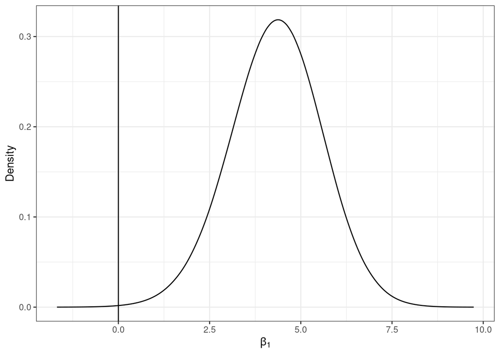

Posterior distribution of the coefficient of covariate AFF.

```r
library(ggplot2)

marginal <- inla.smarginal(res$marginals.fixed$AFF)
marginal <- data.frame(marginal)

ggplot(marginal, aes(x = x, y = y)) +
  geom_line() +
  labs(
    x = expression(beta[1]),
    y = "Density"
  ) +
  geom_vline(xintercept = 0, col = "black") +
  theme_bw()
```

## Mapping relative risks

Inspecting the estimates of the relative risk of lip cancer and their uncertainty for each of the counties:

```r
head(res$summary.fitted.values)
```

```
##                         mean        sd 0.025quant 0.5quant 0.975quant     mode
## fitted.Predictor.01 4.890463 1.4598356   2.667666 4.678187   8.333413 4.286662
## fitted.Predictor.02 4.352802 0.6768641   3.177462 4.300767   5.824938 4.198589
## fitted.Predictor.03 3.502193 1.0215368   1.920791 3.361781   5.888897 3.098193
## fitted.Predictor.04 3.005672 0.8970390   1.631107 2.877994   5.113695 2.640982
## fitted.Predictor.05 3.271259 0.7523615   2.046285 3.186752   4.979916 3.025256
## fitted.Predictor.06 2.883656 0.9236386   1.491192 2.745305   5.072207 2.491301
```

The column `mean` is the mean posterior and the `0.025quant` and `0.975quant` are the 2.5th and 97.5th quantiles, respectively.

Adding these data to `map` to make plotting easier (and the code more readable):

```r
map$RR <- res$summary.fitted.values[, "mean"]
map$LL <- res$summary.fitted.values[, "0.025quant"]
map$UL <- res$summary.fitted.values[, "0.975quant"]
```

Showing the relative risk of lip cancer in the interactive leaflet map:

```r
pal <- colorNumeric(palette = "YlOrRd", domain = map$RR)

labels <- sprintf(
  "<strong> %s </strong> <br/>
  Observed: %s <br/> Expected: %s <br/>
  AFF: %s <br/> SIR: <br/> RR: %s (%s, %s)",
  map$county, map$Y, round(map$E, 2), round(map$AFF, 2), round(map$RR, 2), round(map$LL, 2), round(map$UL, 2)
) |> lapply(htmltools::HTML)

lRR <- leaflet(map) |>
  addTiles() |>
  addPolygons(
    color = "grey",
    weight = 1,
    fillColor = ~ pal(RR),
    fillOpacity = 0.5,
    highlightOptions = highlightOptions(weight = 4),
    label = labels,
    labelOptions = labelOptions(
      style = list(
        "font-weight" = "normal",
        padding = "3px 8px"
      ),
      textsize = "15px", direction = "auto"
    )
  ) |>
  addLegend(
    pal = pal,
    values = ~ RR,
    opacity = 0.5,
    title = "RR"
  )

lRR
```

[interactive chart not shown]

Interactive map of lip cancer relative risk in Scotland counties created with **leaflet**.

## Exceedance probabilities

Probabilities of relative risk estimates being greater than a given threshold are called exceedance probabilities. These are useful to assess unusual elevation of disease risk. Mathematically,
$$P(\theta_i > c) = 1 = P(\theta_i \leq c)$$
in **R-INLA**, calculation is as follows:

```r
1 - inla.pmarginal(q = c, marginal = marg)
```

where `marg` is the marginal distribution of the predictions, and `c` is the threshold value.

In our example, the marginals of the relative risks azre in `res$marginals.fitted.values`, and the marginal corresponding to the first county is in `res$marginals.fitted.values[[1]]`.

Calculating the probability that the relative risk of the first county exceeds 2 (or $P(\theta_1 > 2)$):

```r
marg <- res$marginals.fitted.values[[1]]
exc_prob_2 <- 1 - inla.pmarginal(q = 2, marginal = marg)
exc_prob_2
```

```
## [1] 0.9985092
```

calculating the exceedance probabilities for all counties using the `sapply()` function:

```r
exc <- sapply(
  res$marginals.fitted.values,
  FUN = function(marg){1 - inla.pmarginal(q = 2, marginal = marg)}
)

head(exc)
```

```
## fitted.Predictor.01 fitted.Predictor.02 fitted.Predictor.03 fitted.Predictor.04
##           0.9985092           0.9999996           0.9652871           0.8947453
## fitted.Predictor.05 fitted.Predictor.06
##           0.9802782           0.8449768
```

Adding the exceedance probabilities to `map`:

```r
map$exc <- exc
```

Creating an interactive map of the exceedance probabilities using **leaflet**:

```r
pal <- colorNumeric(palette = "YlOrRd", domain = map$exc)

labels <- sprintf(
  "<strong> %s </strong> <br/>
  Observed: %s <br/> Expected: %s <br/>
  AFF: %s <br/> SIR: %s <br/> RR: %s (%s %s) <br/> P(RR>2): %s",
  map$county, map$Y, round(map$E, 2), map$AFF,
  round(map$SIR, 2), round(map$RR, 2), round(map$LL, 2),
  round(map$UL, 2), round(map$exc, 2)
) |> lapply(htmltools::HTML)

lexc <- leaflet(map) |>
  addTiles() |>
  addPolygons(
    color = "grey",
    weight = 1,
    fillColor = ~ pal(exc),
    fillOpacity = 0.5,
    highlightOptions = highlightOptions(weight = 4),
    label = labels,
    labelOptions = labelOptions(
      style = list(
        "font-weight" = "normal",
        padding = "3px 8px"
      ),
      textsize = "15px",
      direction = "auto"
    )
  ) |>
  addLegend(
    pal = pal,
    values = ~ exc,
    opacity = 0.5,
    title = "P(RR>2)",
    position = "bottomright"
  )

lexc
```

[interactive chart not shown]

Interactive map of exceedance probabilities in Scotland counties created with **leaflet**.